# Pathway Analysis in Metabolomics using Bayesian Statistics

15/04/2021

## Metabolic Profiling

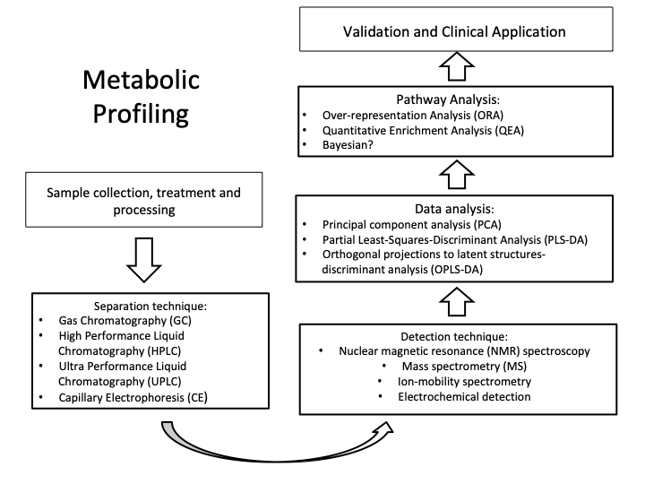

## Metabolic journey

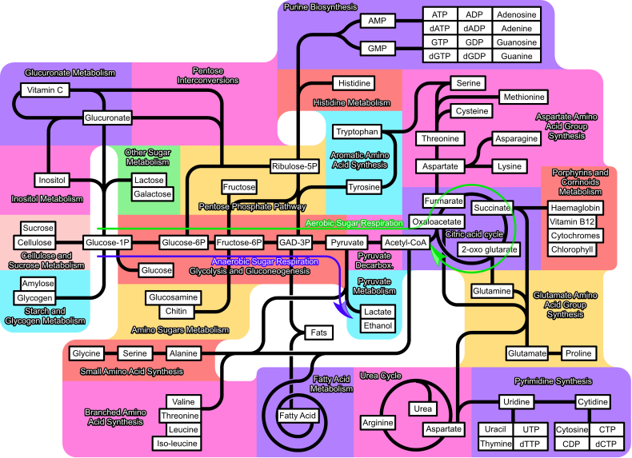

(https://en.wikipedia.org/wiki/Wikipedia_talk:WikiProject_Molecular_Biology/Metabolic_Pathways/Archive_1#/media/File:Metabolism_wip.png)

## Citric Acid Cycle or Tricarboxylic acid (TCA) cycle

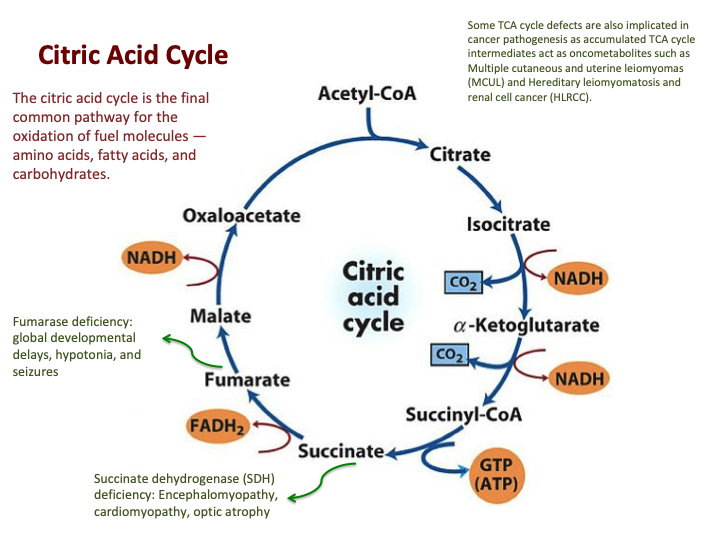

(https://www.sigmaaldrich.com/technical-documents/articles/biofiles/citric-acid-cycle.html)

## Challenge

- So many unknown links between pathways that haven’t been identified.
- To take into account the interaction between pathways and metabolites within the pathway as one dynamic system.
- To include the pathway interaction into metabolic profiling in the pathway analysis.

## Aim

- To integrate the dynamic nature of a biological system in the analysis through Bayesian Statistics.

## Pathway Analysis Methods

Two most common methods of enrichment analysis are:

1. Over-representation analysis (ORA)
2. Quantitative Enrichment Analysis (QEA)

## Over-representation analysis (ORA)

- To evaluate whether a particular set of metabolites is represented more than expected by chance within a given compound list.
- Based on statistical tests on probability distribution like the hypergeometric, binomial or chi-squared.

(Kamburov et al. 2011; Ren et al. 2015; Khatri, Sirota, and Butte 2012; Picart-Armada et al. 2018; Xia and Wishart 2010; Maertens et al. 2017)

## Quantitative Enrichment Analysis (QEA)

- It is directly based on the compound concentration values.
- It has the potential to discover “subtle but consistent” changes among compounds within the same biological pathway.
- Uses a generalized linear model to estimate the correlation between compound concentration profiles and phenotype.

(Ren et al. 2015; Xia and Wishart 2010; Maertens et al. 2017)

## Graph representation of ORA and QEA

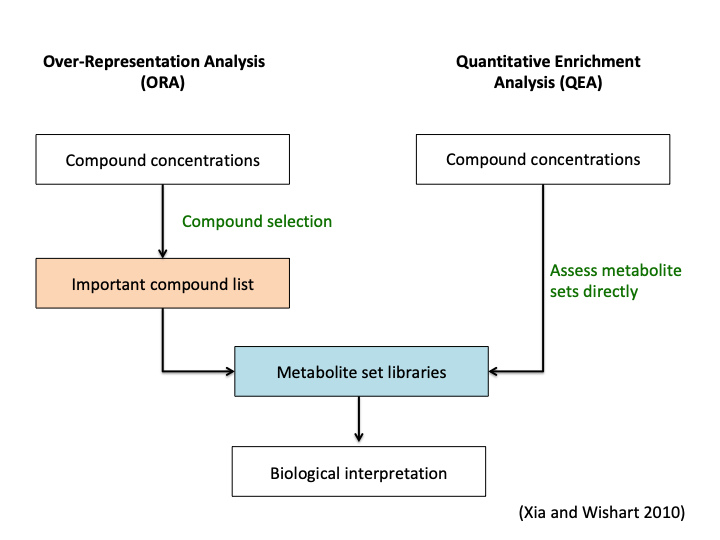

## Example - ORA and QEA Data background

- Urinary metabolite concentrations from 77 cancer patients.
- Phenotype: Cachexic; Healthy
- Compound list (first 15 alphabetical order)
  - Acetoacetic acid
  - Beta-Alanine
  - Creatine
  - Dimethylglycine
  - Fumaric acid
  - Glycine
  - Homocysteine
  - L-Cysteine
  - L-Isolucine
  - L-Phenylalanine
  - L-Serine
  - L-Threonine
  - L-Tyrosine
  - L-Valine
  - Phenylpyruvic acid

## Example of ORA and QEA result

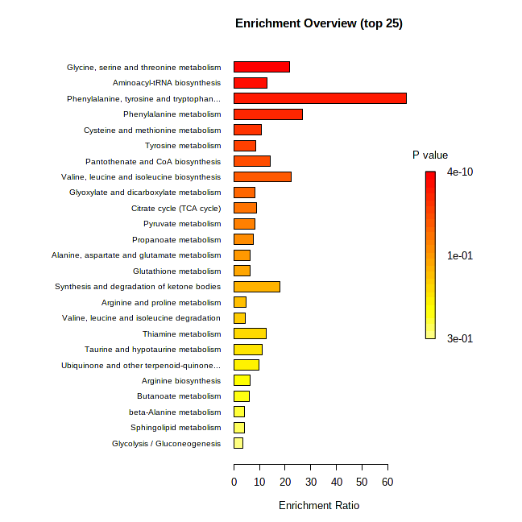

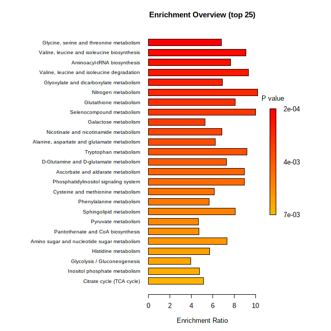

- P-value indicates the probability of seeing at least a particular number of metabolites from a certain metabolite set in a given compound list.
- P-values have been adjusted for multiple testing.

## Current Limitations of ORA and QEA

- Substantial loss of information
  - With ORA, only metabolites showing significant difference between two study groups are used and the rest are ignored.
- Improper independence assumption
  - each metabolite and pathway is assumed to be independent of others

(Kamburov et al. 2011; Ren et al. 2015; Khatri, Sirota, and Butte 2012; Picart-Armada et al. 2018; Xia and Wishart 2010)

## Bayesian Statistics

- It is a probabilistic model that uses Bayes’ Theorem to update the probability for a hypothesis as more evidence becomes available.
  - i.e. it uses probabilities as a tool to quantify uncertainty.

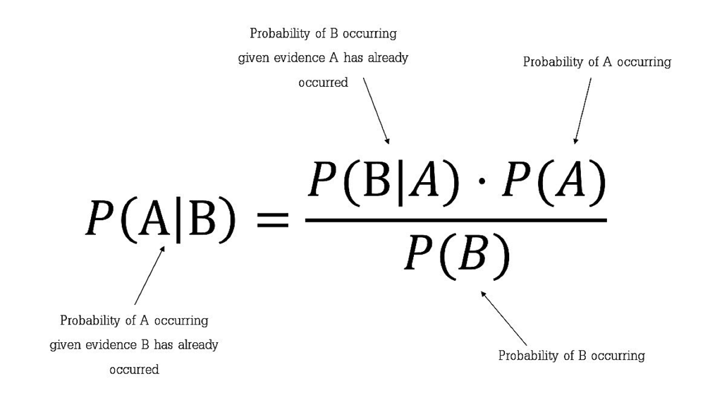

## Example

We want to know what is the probability that it rained given that it is wet outside?

A = it rained today, B = wet sidewalk.

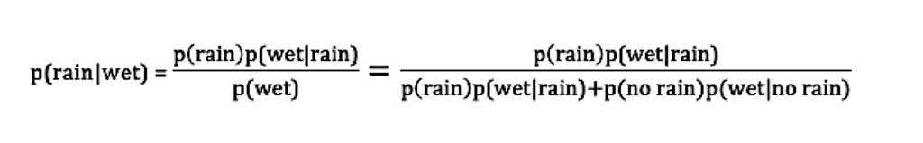

p(rain) – our initial beliefs – called prior.

p(rain|wet) – our final beliefs – called posterior.

p(wet) – how plausible is the evidence? what is the likelihood that it is wet outside given it rained and not rained. This is to ensure that the posterior is the correct probability distribution.

## Bayesian workflow

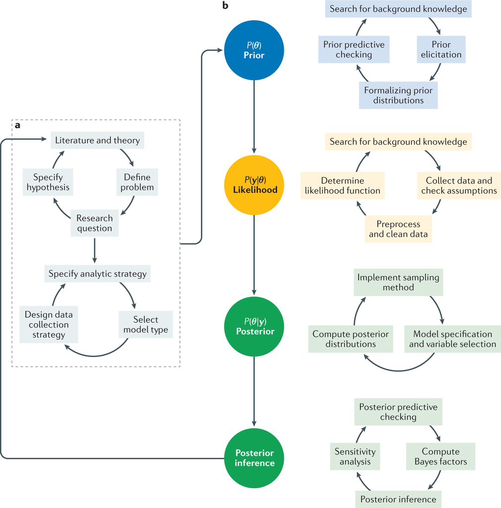

(Schoot et al. 2021)

## Strength of Bayesian

- Useful for modelling networks of biological reactions
  - number of parameters >> number of samples
- Can accommodate structure of the data into the model
  - It allows us to group the metabolites according to the pathways they sit under.
- It takes account uncertainty
- Information sharing amongst groups.

## References

Kamburov, Atanas, Rachel Cavill, Timothy MD Ebbels, Ralf Herwig, and Hector C Keun. 2011. “Integrated Pathway-Level Analysis of Transcriptomics and Metabolomics Data with IMPaLA.” *Bioinformatics* 27 (20): 2917–18.

Khatri, Purvesh, Marina Sirota, and Atul J Butte. 2012. “Ten Years of Pathway Analysis: Current Approaches and Outstanding Challenges.” *PLoS Comput Biol* 8 (2): e1002375.

Maertens, Alexandra, Mounir Bouhifd, Liang Zhao, Shelly Odwin-DaCosta, Andre Kleensang, James D Yager, and Thomas Hartung. 2017. “Metabolomic Network Analysis of Estrogen-Stimulated MCF-7 Cells: A Comparison of Overrepresentation Analysis, Quantitative Enrichment Analysis and Pathway Analysis Versus Metabolite Network Analysis.” *Archives of Toxicology* 91 (1): 217–30.

Picart-Armada, Sergio, Francesc Fernández-Albert, Maria Vinaixa, Oscar Yanes, and Alexandre Perera-Lluna. 2018. “FELLA: An r Package to Enrich Metabolomics Data.” *BMC Bioinformatics* 19 (1): 1–9.

Ren, Sheng, Anna A Hinzman, Emily L Kang, Rhonda D Szczesniak, and Long Jason Lu. 2015. “Computational and Statistical Analysis of Metabolomics Data.” *Metabolomics* 11 (6): 1492–1513.

Schoot, Rens van de, Sarah Depaoli, Ruth King, Bianca Kramer, Kaspar Märtens, Mahlet G Tadesse, Marina Vannucci, et al. 2021. “Bayesian Statistics and Modelling.” *Nature Reviews Methods Primers* 1 (1): 1–26.

Xia, Jianguo, and David S Wishart. 2010. “MSEA: A Web-Based Tool to Identify Biologically Meaningful Patterns in Quantitative Metabolomic Data.” *Nucleic Acids Research* 38 (suppl_2): W71–77.